# fundamentos

$y_{ij}$ ~ $Ga(y|\alpha, \beta)$ i - individuo i =1, …, 70 j - mediciones para cada individuo i y - concentración de glucosa en la sangre

$\alpha, \beta$ desconocidas

Los datos diabetes-data.csv contienen la información de medición de glucosa en la sangre de 70 pacientes con diabetes observados en diferentes momentos del tiempo (horas, días, semanas, meses).

El contenido y formato de los datos es el siguiente:

1. Fecha (date) en formato MM-DD-YYYY
2. Hora (time) en formato XX:YY
3. Código (code)
4. Nivel de glucosa (value)
5. Indicadora de paciente (individual)

Los datos de concentración en la sangre se obtienen de dos fuentes:

Mediciones electrónicas automáticas Registros escritos en papel. Las mediciones eletrónicas automáticas se obtienen con etiquetas de tiempo específicas, mientras que las mediciones obtenidas de los registros *escritos* corresponden a *horarios ficticios* con la siguiente relación: Desayuno (08:00), comida (12:00), cena (18:00), y hora de dormir (22:00).

El campo code corresponde al tipo de insulina administrada al paciente.

Nota: La información de la adminitración de insulina, en este momento, es irrelevante.

```r
library(tidyverse)
library(readr)
library(stringr)
library(lubridate)
library(ggplot2)

theme_set(theme_bw())
# Lectura de datos
diabetes <- read_csv("datos/data_diabetes.csv", col_types = list(
  X1 = col_integer(),
  date = col_character(),
  time = col_time(format = ""),
  code = col_integer(),
  value = col_double(),
  individual = col_integer())) %>%
  select(-X1)

# Catalogo de codigos
catalogo_code <- read_csv("docs/catalogo_code.csv")
```

```r
# Base de datos
bd_diabetes <- diabetes %>%
  left_join(catalogo_code)

summary(bd_diabetes)
     date               time               code          value
 Length:29264       Length:29264      Min.   : 4.0   Min.   :  0.00
 Class :character   Class1:hms        1st Qu.:33.0   1st Qu.:  6.00
 Mode  :character   Class2:difftime   Median :48.0   Median : 24.00
                    Mode  :numeric    Mean   :46.5   Mean   : 79.42
                                      3rd Qu.:60.0   3rd Qu.:142.00
                                      Max.   :72.0   Max.   :501.00
                                                     NA's   :8
   individual      atributo
 Min.   : 1.00   Length:29264
 1st Qu.:21.00   Class :character
 Median :34.00   Mode  :character
 Mean   :36.45
 3rd Qu.:55.00
 Max.   :70.00

glimpse(bd_diabetes)
Observations: 29,264
Variables: 6
$ date       <chr> "04-21-1991", "04-21-1991", "04-21-1991", "04-21-19...
$ time       <time> 09:09:00, 09:09:00, 09:09:00, 17:08:00, 17:08:00, ...
$ code       <int> 58, 33, 34, 62, 33, 48, 58, 33, 34, 33, 62, 33, 58,...
$ value      <dbl> 100, 9, 13, 119, 7, 123, 216, 10, 13, 2, 211, 7, 25...
$ individual <int> 1, 1, 1, 1, 1, 1, 1, 1, 1, 1, 1, 1, 1, 1, 1, 1, 1, ...
$ atributo   <chr> "medición de glucosa en sangre antes del desayuno",...
```

1. ¿Existe discrepancia (en media o distribucional) entre las mediciones reportadas de registros escritos en papel y las que son reportadas electrónicamene?

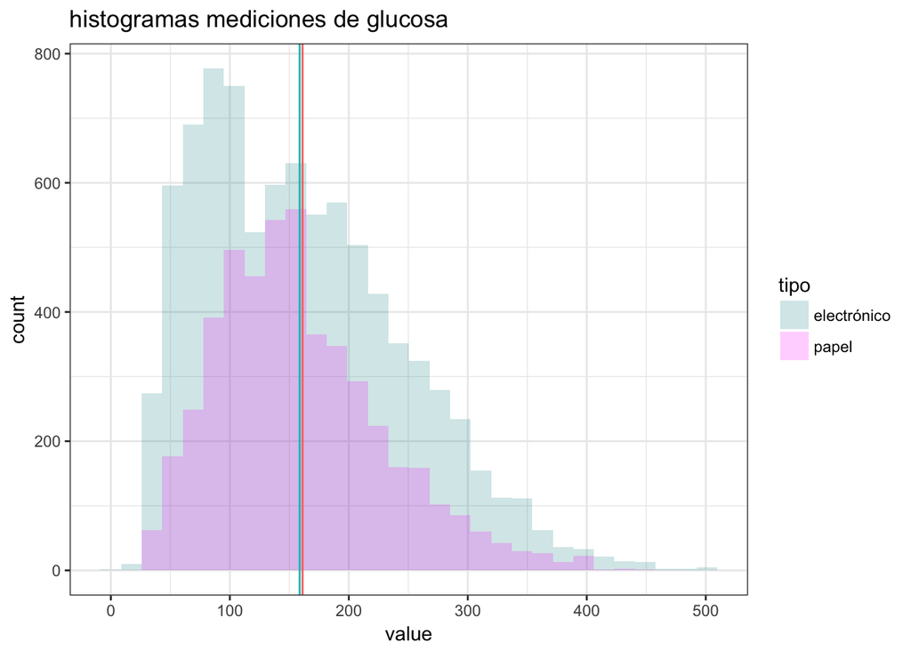

```r
bd_mediciones <- bd_diabetes %>%
  mutate(atributo = str_replace_all(atributo, " ", "_")) %>%
  filter(str_detect(atributo, "medición"))

# separamos escritos vs. aparato
escritos_hrs <- c(8, 12, 18, 22)
bd_mediciones <- bd_mediciones %>%
  mutate(tipo=ifelse((hour(time) %in% escritos_hrs) &
          (minute(time) == 0), 'papel', 'electrónico'))

# Plot
mean_papel <- subset(bd_mediciones, tipo == 'papel') %>%
  select(value) %>% flatten_dbl() %>% mean(na.rm = TRUE)
mean_electronicos <- subset(bd_mediciones, tipo == 'electrónico') %>%
  select(value) %>% flatten_dbl() %>% mean(na.rm = TRUE)

ggplot(bd_mediciones, aes(x=value, fill=tipo)) +
  geom_histogram(alpha=0.2, position="identity") +
  scale_fill_manual(values=c("darkcyan", "magenta")) +
  geom_vline(aes(xintercept = mean_papel, color="magenta"),
             show.legend = FALSE) +
  geom_vline(aes(xintercept = mean_electronicos, color="darkcyan"),
             show.legend = FALSE ) +
  ggtitle("histogramas mediciones de glucosa")
```

2. ¿ Existe discrepancia entre las mediciones de glucosa de los pacientes entre las cuatro horas del día donde se miden?

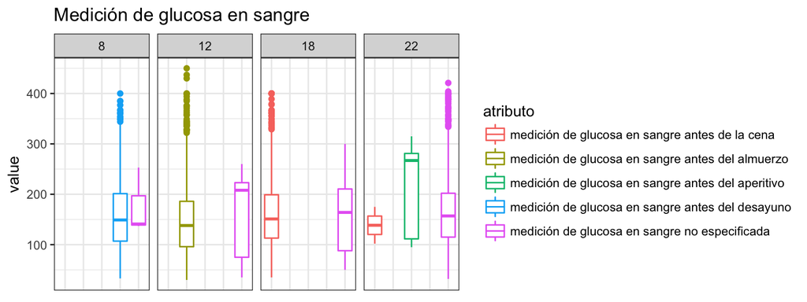

```r
mediciones_4 <- bd_diabetes %>%
  filter(str_detect(atributo, "medición")) %>%
  filter(hour(time) %in% c(8, 12, 18, 22), minute(time) == 0, second(time) == 0)

ggplot(mediciones_4) +
  geom_boxplot(aes(x = atributo, y = value, color = atributo)) +
  facet_grid(~as.factor(hour(time))) +
  theme(axis.text.x=element_blank(),
        axis.ticks.x=element_blank(),
        axis.title.x=element_blank()) +
  ggtitle("Medición de glucosa en sangre")
```

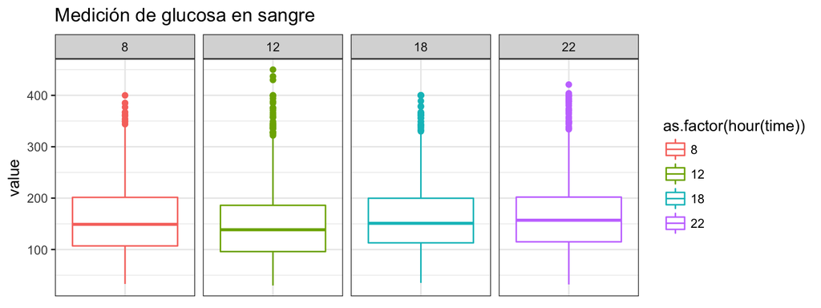

```r
ggplot(mediciones_4) +
  geom_boxplot(aes(x = "1", y = value, color = as.factor(hour(time)))) +
  facet_grid(~as.factor(hour(time))) +
  theme(axis.text.x=element_blank(),
        axis.ticks.x=element_blank(),
        axis.title.x=element_blank()) +
  ggtitle("Medición de glucosa en sangre")
```

3. ¿ Existe discrepancia de las mediciones de glucosa entre pacientes?

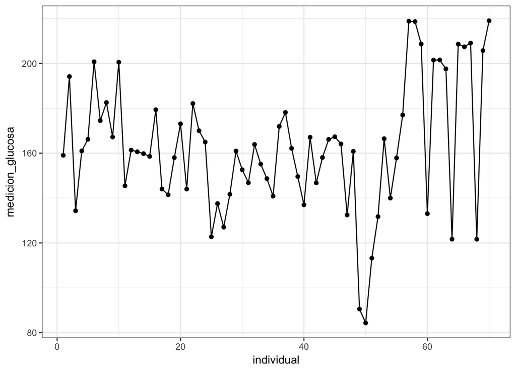

```r
bd_mediciones %>%
  group_by(individual) %>%
   filter(atributo %in% atributo[str_detect(atributo, "medición")]) %>%
  summarise(medicion_glucosa = mean(value, na.rm = TRUE)) %>%
  ggplot(aes(x = individual, y = medicion_glucosa)) +
  geom_point()+
  geom_line()
```

4. ¿ Existe discrepancia entre las mediciones de glucosa asociadas con la administración de insulina con respecto a las demás?

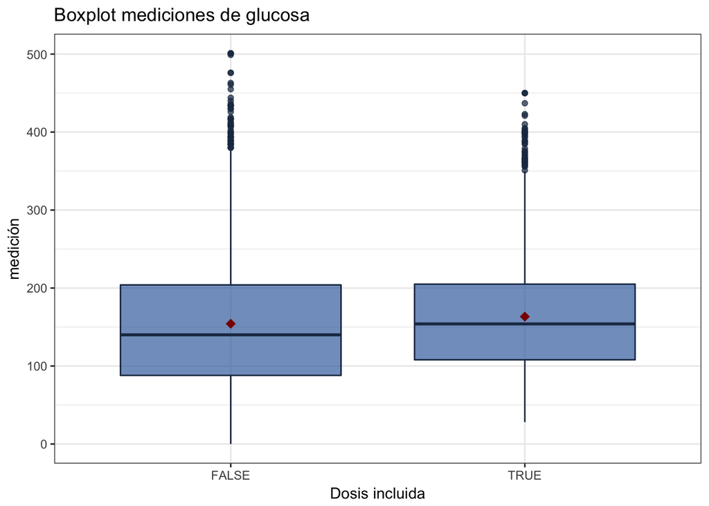

```r
base_dosis_med <- bd_diabetes %>%
  filter(str_detect(atributo, c("medición", "dosis")))

base_dosis_med <-base_dosis_med %>%
  mutate(ID = group_indices_(base_dosis_med,
                           .dots=c("individual", "date", "time")))

base_dosis_med <- base_dosis_med  %>%
  mutate(tipo = ifelse(startsWith(atributo,"medición"),
                       "medición", "dosis")) %>%
  select(ID, individual, date, time, value, tipo) %>%
  distinct(individual, date, time, tipo, .keep_all = TRUE) %>%
  spread(tipo, value) %>%
  subset( !is.na(medición)) %>%
  mutate(dosis=ifelse(!is.na(dosis), TRUE, FALSE))

# Plot
ggplot(base_dosis_med, aes(x = dosis, y = medición)) +
  geom_boxplot(fill = "#4271AE", colour = "#1F3552",
               alpha = 0.7) +
  stat_summary(fun.y=mean, colour="darkred", geom="point",
               shape=18, size=3, show.legend = FALSE) +
  scale_x_discrete(name = "Dosis incluida") +
  ggtitle("Boxplot mediciones de glucosa")
```

5. ¿Existe una discrepancia clara entre los pacientes que reportan sus niveles de glocosa depués de haber ingerido más alimentos de lo usual?

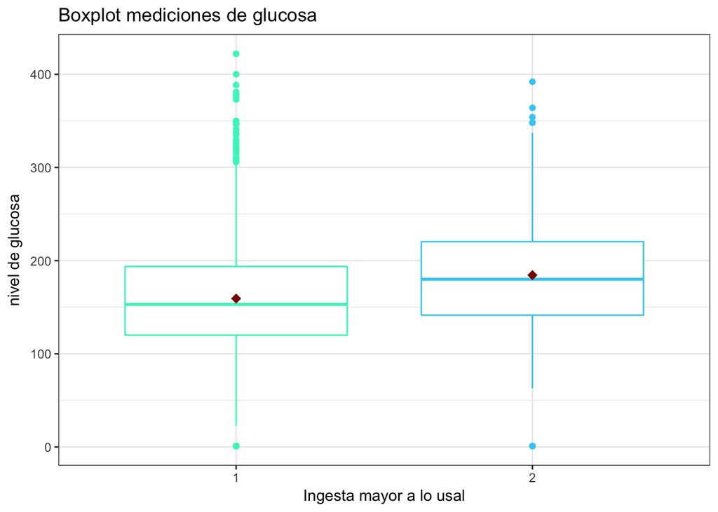

```r
base_ingesta <- bd_diabetes %>%
  filter(atributo %in% c(atributo[str_detect(atributo, "medición")],
                         atributo[str_detect(atributo, "ingestión de comida mayor")]),
         !is.na(atributo)) %>%
  mutate(tipo = ifelse(str_detect(atributo,"medición"), "medicion", "ingesta")) %>%
  group_by(date, individual, tipo) %>%
  summarise(media_glucosa = mean(value)) %>%
  spread(tipo, media_glucosa, fill=1) %>%
  ungroup() %>%
  mutate(ingesta = ifelse(ingesta == 0, 2, ingesta))

ggplot(base_ingesta, aes(x = as.factor(ingesta), y = medicion, color = as.factor(ingesta))) +
  geom_boxplot(color = c("#42f4c5","#41cdf4")) +
  stat_summary(fun.y=mean, colour="darkred", geom="point",
               shape=18, size=3) +
  scale_color_manual(name = "Ingesta", values = c("Sí", "No")) +
  labs(title = "Boxplot mediciones de glucosa", x = "Ingesta mayor a lo usal",
       y = "nivel de glucosa")
```

### Modelo pregunta 5

- ¿Existe una discrepancia clara entre los pacientes que reportan sus niveles de glocosa depués de haber ingerido más alimentos de lo usual?

Para esta pregunta se realizó un modelo jeráquico, la jerarquía se aplica a nivel indivuo en donde los individuos comparten varianza. Esto nos permite mejorar la precisión de las estimaciones de los parámetros e incorporar incertidumbre en la estimaciones.

En este primer modelo no se busca predecir la glucosa sino verificar si existe discrepancia clara entre los pacientes que ingieren más alimentos de lo usual.

Se crea una base con el promedio diario de glucosa por individuo con un indicador que especifica si en ese día ingirió más alimentos que lo normal.

```r
library(R2jags)
prob<-function(x){
  out<-min(length(x[x>0])/length(x),length(x[x<0])/length(x))
  out
}

base_ingesta <- bd_diabetes %>%
  filter(atributo %in% c(atributo[str_detect(atributo, "medición")],
                         atributo[str_detect(atributo, "ingestión de comida mayor")]),
         !is.na(atributo)) %>%
  mutate(tipo = ifelse(str_detect(atributo,"medición"), "medicion", "ingesta")) %>%
  group_by(date, individual, tipo) %>%
  summarise(media_glucosa = mean(value)) %>%
  spread(tipo, media_glucosa, fill=1) %>%
  ungroup() %>%
  mutate(ingesta = ifelse(ingesta == 0, 2, ingesta)) %>%
  filter(medicion>2)

n <- nrow(base_ingesta)
n_indiv <- base_ingesta$individual %>%
  unique() %>%
  length()
data<-list("n"=n, "n_indv" = n_indiv, "y"=base_ingesta$medicion, "x" = base_ingesta$ingesta,
           "indiv" = base_ingesta$individual)

inits<-function(){list(alpha = rep(0,n_indiv), beta = rep(0,2), yf1=rep(1,n))}

parameters<-c("alpha","beta.adj", "yf1")

mod.reg <-jags(data,inits,parameters,model.file="modelo_ingesta.txt",
               n.iter=30000,n.chains=1,n.burnin=3000, n.thin = 1)
Compiling model graph
   Resolving undeclared variables
   Allocating nodes
Graph information:
   Observed stochastic nodes: 3853
   Unobserved stochastic nodes: 7779
   Total graph size: 23408

Initializing model
```

- Simulaciones de los parámetros

```r
out<-mod.reg$BUGSoutput$sims.list
out.sum<-mod.reg$BUGSoutput$summary
```

En esta gráfica se observa que hay una discrepancia clara entre los pacientes que ingieren más alimentos que lo usal. $Beta1$ es negativa y representa a los días que no se ingirió mayor cantidad de almientos y $Beta2$ es positiva lo cual significa que el nivel de glucosa aumenta si se come más de lo normal.

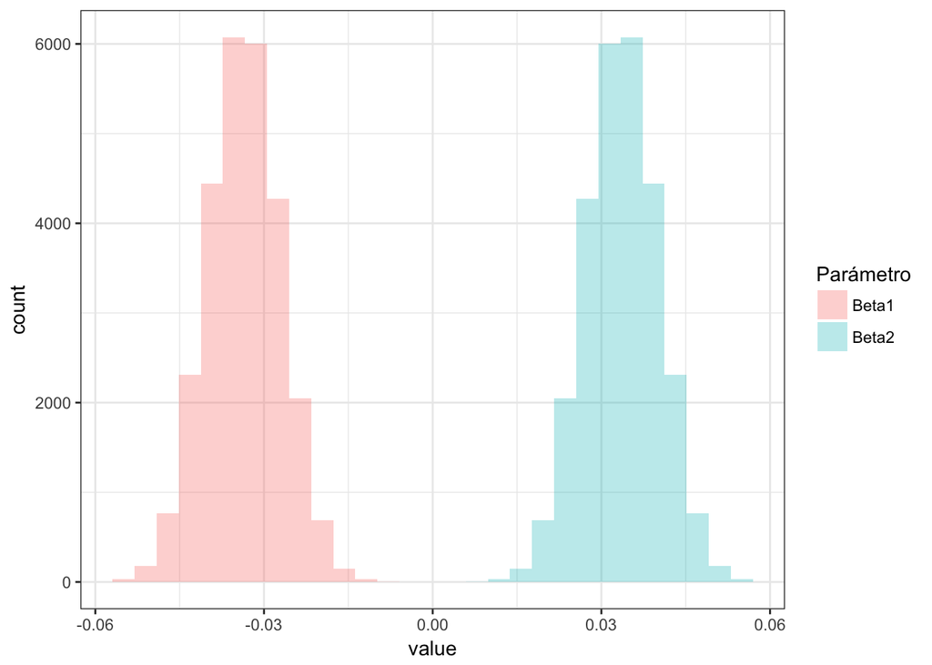

```r
data.frame(Beta1 = out$beta.adj[,1], Beta2 = out$beta.adj[,2]) %>%
  gather() %>%
  ggplot(aes(x = value, fill = key)) +
  geom_histogram(alpha = .3) +
  scale_fill_discrete(name = "Parámetro")
```

Se grafica el parámetro $alpha$ para observar si existe alguna diferencia entre individuos. Observamos que se comportan similar.

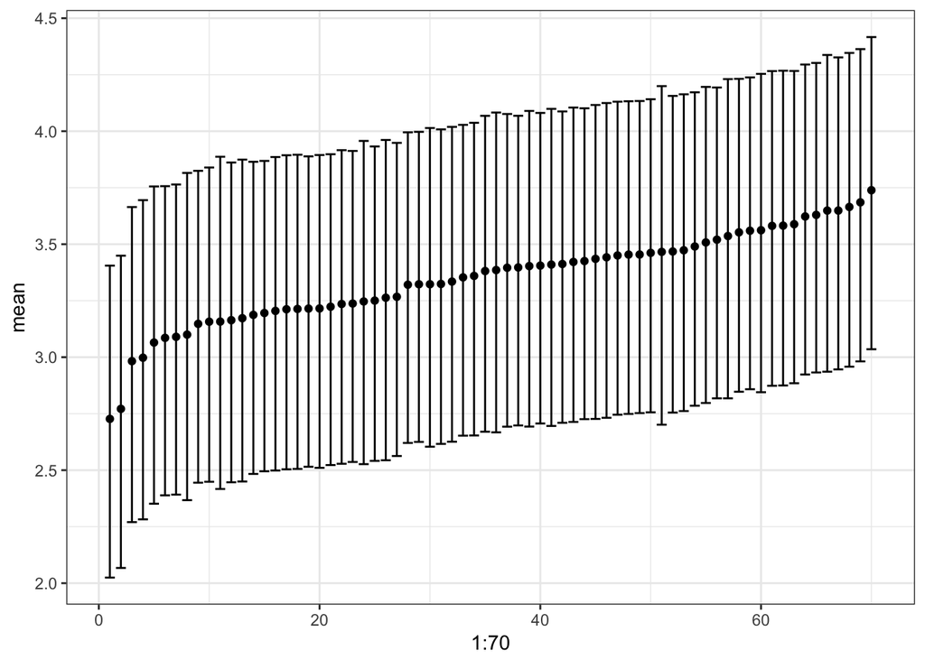

```r
out.alpha<-out.sum[grep("alpha",rownames(out.sum)),]

out.alpha %>%
  data.frame() %>%
  arrange(mean) %>%
  ggplot(aes(x = 1:70, y = mean)) +
  geom_point() +
  geom_errorbar(aes(x=1:70, ymin = X2.5., ymax=X97.5.))
```

- Resúmenes estadístico de los parámetros (nodos) monitoreados

```r
out.sum[grep("beta", rownames(out.sum)), c(1,3,7)]
                   mean        2.5%       97.5%
beta.adj[1] -0.03356736 -0.04632913 -0.02090920
beta.adj[2]  0.03356736  0.02090920  0.04632913
```

- DIC

```r
out.dic<-mod.reg$BUGSoutput$DIC
out.dic
[1] 41322.87
```

- R2

```r
out.yf<-out.sum[grep("yf1",rownames(out.sum)),]

r2 <- cor(base_ingesta$medicion, out.yf[,1])^2
r2
[1] 0.2596486
```

- Devianza

```r
mean(out$deviance)
[1] 38796.22
```

Se realizó otra base y se aplica el mismo modelo para predecir la glucosa por individuo, creando una base con la media por individuo de glucosa separando si el paciente tuvo una ingesta mayor de alimentos que la usual.

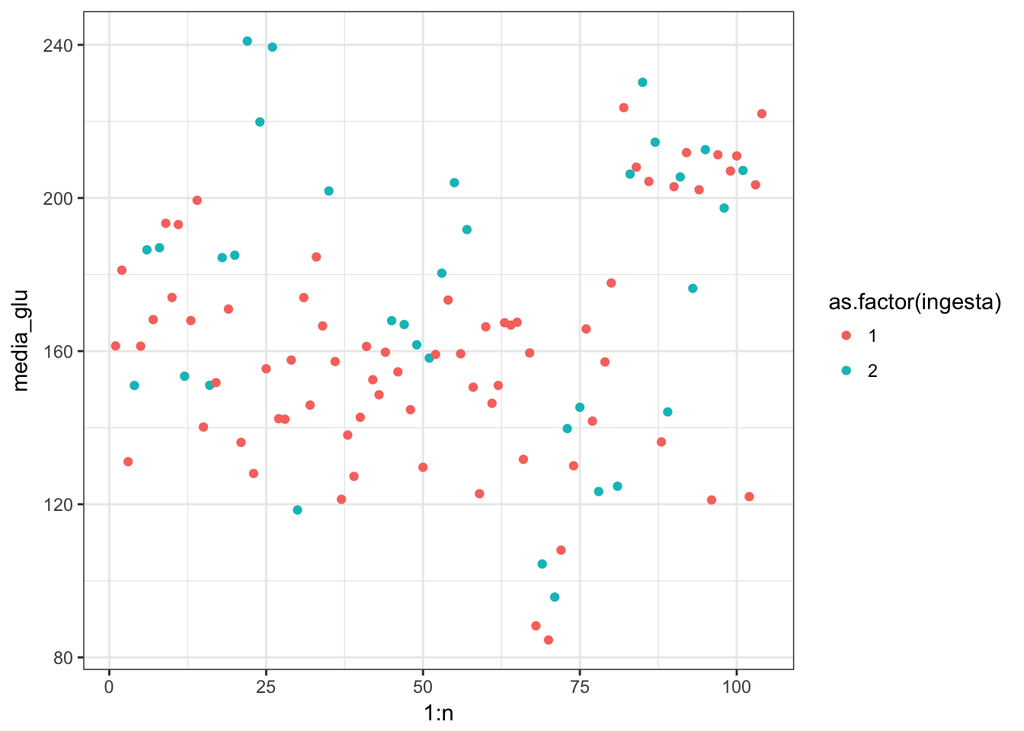

```r
base_ingesta <- bd_diabetes %>%
  mutate(hora = hour(time)) %>%
  filter(atributo %in% c(atributo[str_detect(atributo, "medición")], atributo[str_detect(atributo, "ingestión de comida mayor")]),
         !is.na(atributo)) %>%
  mutate(tipo = ifelse(str_detect(atributo,"medición"), "medicion", "ingesta")) %>%
  group_by(date, individual, tipo) %>%
  summarise(media_glucosa = mean(value)) %>%
  spread(tipo, media_glucosa, fill = 1) %>%
  ungroup() %>%
  mutate(ingesta = ifelse(ingesta == 0, 2, ingesta),
         unos = 1) %>%
  group_by(individual, ingesta) %>%
  summarise(media_glu = mean(medicion)) %>%
  filter(media_glu>2)

n_indiv <- base_ingesta$individual %>%
  unique() %>%
  length()

n <- nrow(base_ingesta)

base_ingesta %>%
  ggplot(aes(x = 1:n, y = media_glu, color=as.factor(ingesta))) +
  geom_point()
```

```r
data<-list("n"=n, "n_indv" = n_indiv, "y"=base_ingesta$media_glu, "x" = base_ingesta$ingesta,
           "indiv" = base_ingesta$individual)

inits<-function(){list(alpha = rep(0,n_indiv), beta = rep(0,2), yf1=rep(1,n))}

parameters<-c("alpha","beta.adj", "yf1")

mod.reg <-jags(data,inits,parameters,model.file="modelo_ingesta.txt",
               n.iter=30000,n.chains=1,n.burnin=3000, n.thin = 1)
Compiling model graph
   Resolving undeclared variables
   Allocating nodes
Graph information:
   Observed stochastic nodes: 104
   Unobserved stochastic nodes: 281
   Total graph size: 914

Initializing model
```

- Gráfica observado vs predicción

Con el cambio de base las predcción es mejor.

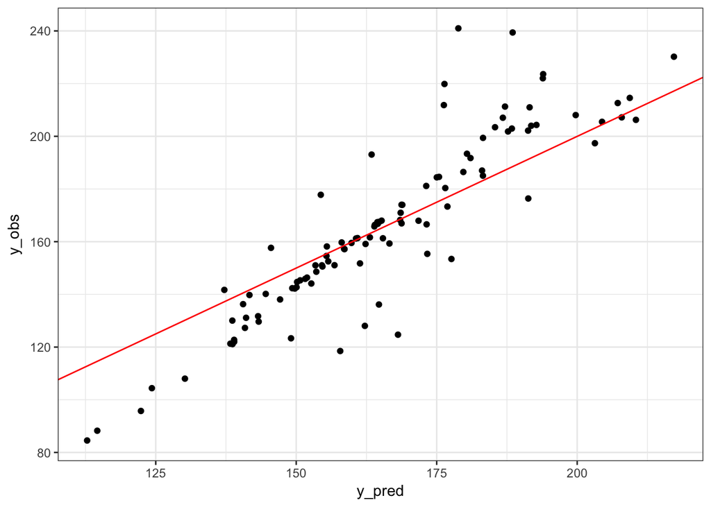

```r
out<-mod.reg$BUGSoutput$sims.list
out.sum<-mod.reg$BUGSoutput$summary
out.yf<-out.sum[grep("yf1",rownames(out.sum)),]
data.frame(y_obs = base_ingesta$media_glu, y_pred = out.yf[,1]) %>%
  ggplot(aes(x = y_pred, y = y_obs)) +
  geom_point() +
  geom_abline(a = 0, b = 1, color = "red")
```

- Intervalos de confianza

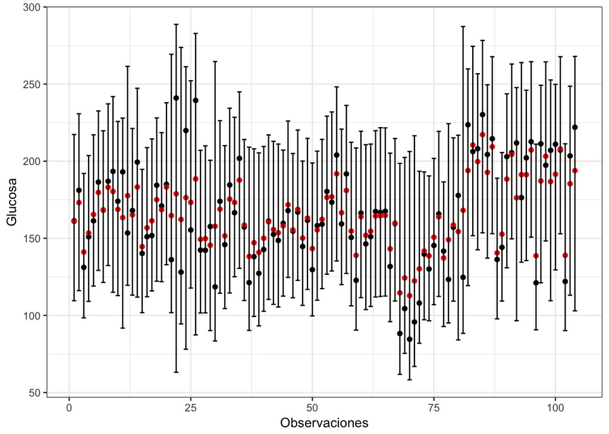

```r
data.frame(y_obs = base_ingesta$media_glu, y_pred = out.yf[,1], y_inf = out.yf[,3],
           y_sup = out.yf[,7]) %>%
  ggplot() +
  geom_point(aes(x = 1:n, y = y_obs)) +
  geom_point(aes(x = 1:n, y = y_pred), color = "red") +
  geom_errorbar(aes(x = 1:n, ymin = y_inf, ymax=y_sup))  +
  labs(x = "Observaciones", y = "Glucosa")
```

- Simulaciones de los parámetros

Observamos que las betas sí nos indican una discrepancia entre la diferencia de la ingesta de alimentos pero no es tan clara como el modelo anterior.

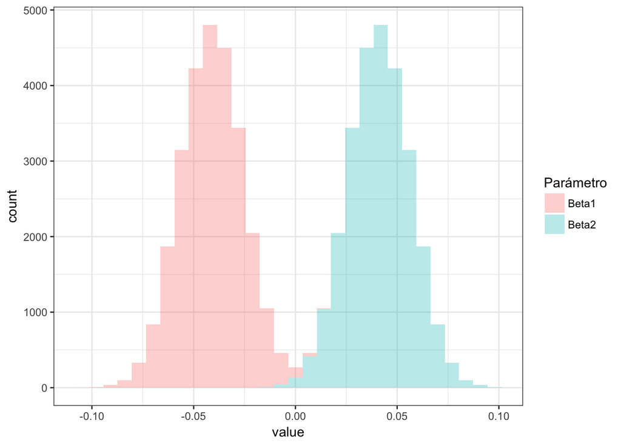

```r
data.frame(Beta1 = out$beta.adj[,1], Beta2 = out$beta.adj[,2]) %>%
  gather() %>%
  ggplot(aes(x = value, fill = key)) +
  geom_histogram(alpha = .3) +
  scale_fill_discrete(name = "Parámetro")
```

Se grafica el parámetro $alpha$ para observar si existe alguna diferencia entre individuos. Observamos que se comportan similar.

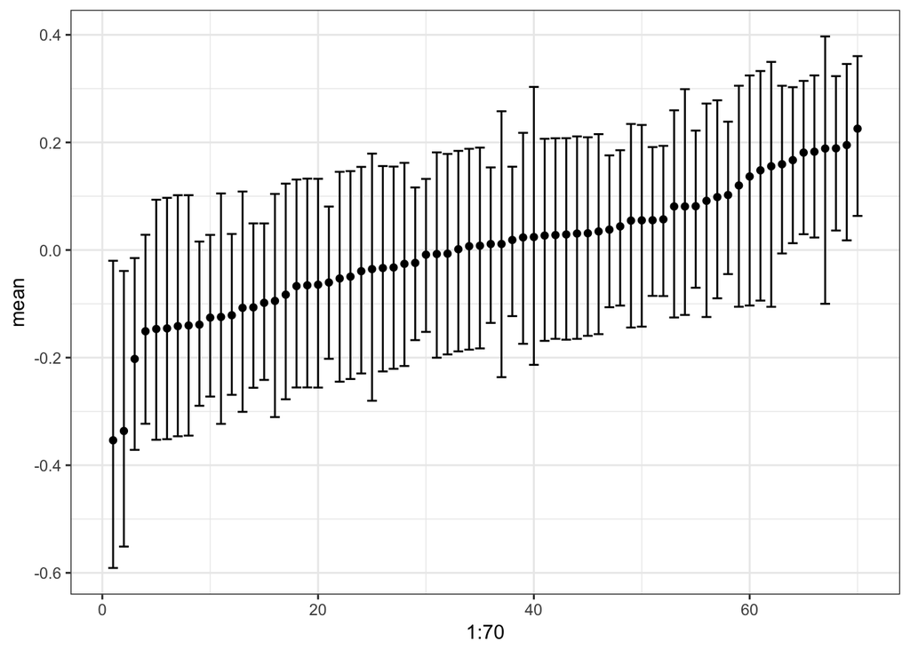

```r
out.alpha<-out.sum[grep("alpha",rownames(out.sum)),]

out.alpha %>%
  data.frame() %>%
  arrange(mean) %>%
  ggplot(aes(x = 1:70, y = mean)) +
  geom_point() +
  geom_errorbar(aes(x=1:70, ymin = X2.5., ymax=X97.5.))
```

En este modelo se obtiene un mejor DIC y $R^2$.

```r
out.dic<-mod.reg$BUGSoutput$DIC
out.dic
[1] 1010.148

cor(base_ingesta$media_glu, out.yf[,1])^2
[1] 0.8125472
```